# LAB1

1/14/2019

## Information

- Lab session: Thursday 4:40 - 5:55 pm, Gray 228.
- Office hour: Wednesday 12:00 - 1:00 pm, Old Chem 025.
- Homework submission: via slack.
- Contact me: via slack.
- Lab materials see https://github.com/YunranChen/STA650Lab. (will be posted 1 day before)

## Outline

- Basic introduction on network analysis using R.
  - R package `igraph`
    - create networks (predifined structures; specific graphs; graph models; adjustments)
    - Edge, vertex and network attributes
    - Network and node descriptions
  - R package `statnet` (ERGM,…)
- Collecting network data
  - **Web API requesting** (Twitter, Reddit, IMDB, or more)
  - Useful websites (SNAP, or more)
- Visualization
  - static networks and dynamic networks
- Network analysis

## `igraph` vs `statnet`

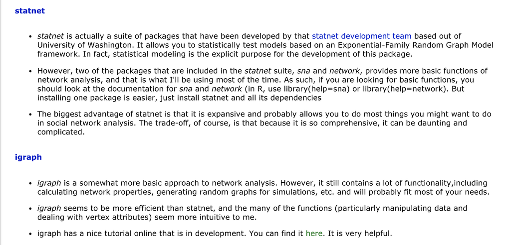

## `igraph`

- Official website (handbook): http://igraph.org/r/
- Tutorial: http://kateto.net/networks-r-igraph
- Book: https://sites.fas.harvard.edu/~airoldi/pub/books/BookDraft-CsardiNepuszAiroldi2016.pdf

## Preparation

```r
#install.packages("igraph")
#install.packages("igraphdata")
library(igraph)
library(igraphdata)
```

## 1. Create simple networks

- `graph(edges,n,directed,isolates)`
- `graph_from_literal`

## 1.1 `graph(edges,n,directed,isolates)`

an undirected graph with 3 edges:

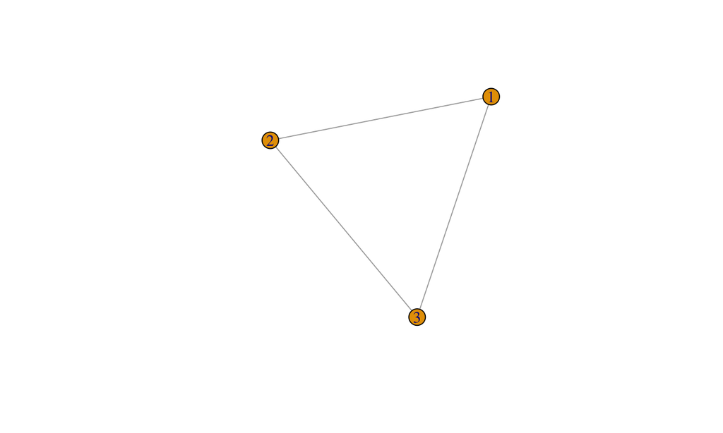

```r
g1 <- graph( edges=c(1,2, 2,3, 3,1), n=3, directed=F )
plot(g1)
```

n can be greater than number of vertices in the edge list

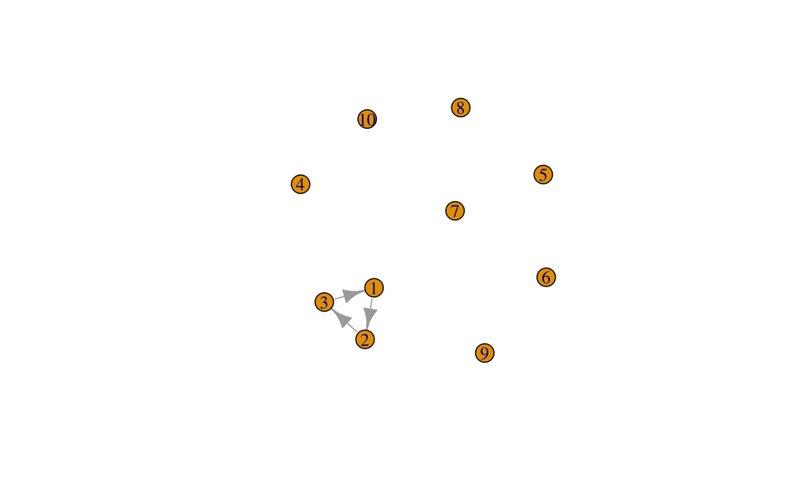

```r
g2 <- graph( edges=c(1,2, 2,3, 3,1), n=10 ) # now with 10 vertices, and directed by default
plot(g2)
```

named vertices

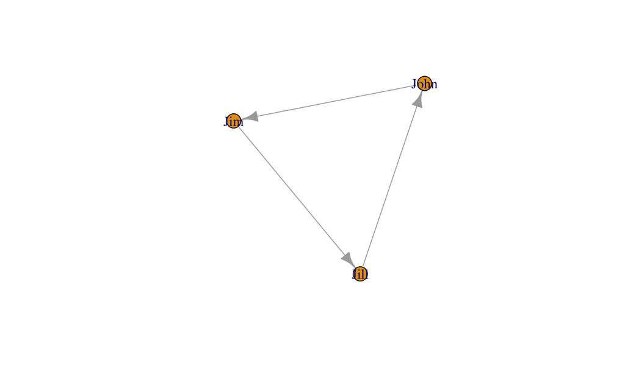

```r
g3 <- graph( c("John", "Jim", "Jim", "Jill", "Jill", "John"))
# When the edge list has vertex names, the number of nodes is not needed
plot(g3)
```

named vertices without edges

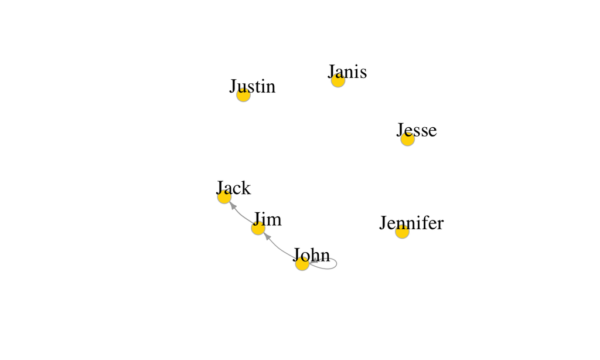

```r
g4 <- graph( c("John", "Jim", "Jim", "Jack", "Jim", "Jack", "John", "John"),
             isolates=c("Jesse", "Janis", "Jennifer", "Justin") )
# In named graphs we can specify isolates by providing a list of their names.
set.seed(1)
plot(g4, edge.arrow.size=.5, vertex.color="gold", vertex.size=15,
     vertex.frame.color="gray", vertex.label.color="black",
     vertex.label.cex=1.5, vertex.label.dist=2, edge.curved=0.2)
```

## 1.2 `graph_from_literal`

Small graphs can also be generated with a description of this kind:

- '-' for undirected tie, "+-' or "-+" for directed ties pointing left & right,
- "++" for a symmetric tie, and ":" for sets of vertices

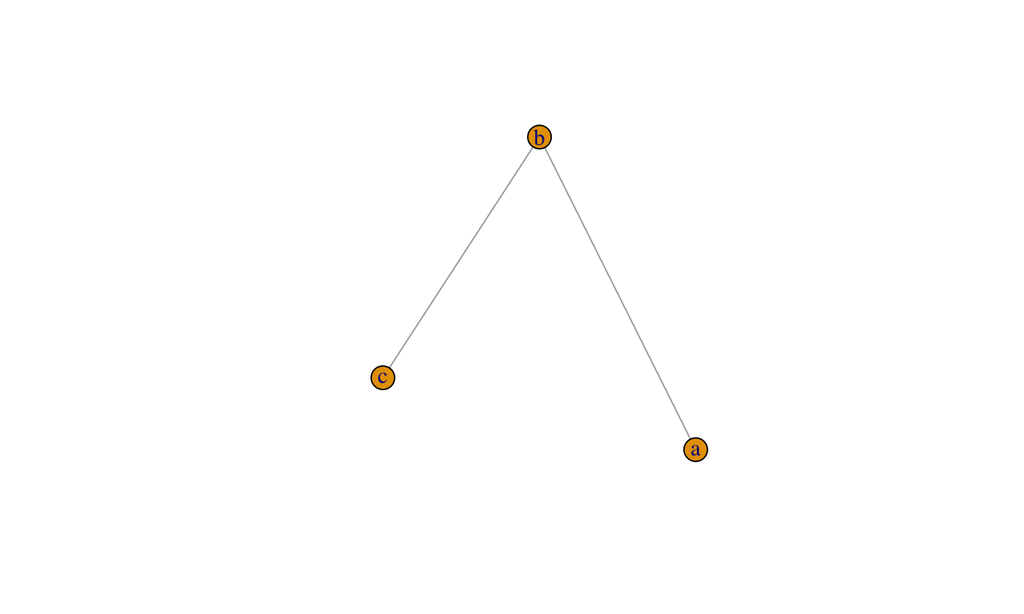

```r
plot(graph_from_literal(a---b, b---c)) # the number of dashes doesn't matter
```

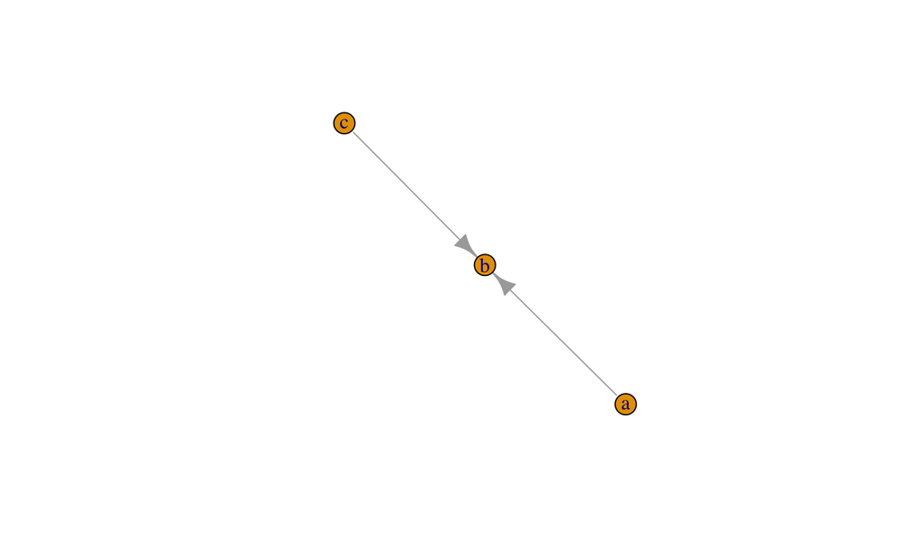

```r
plot(graph_from_literal(a--+b, b+--c))
```

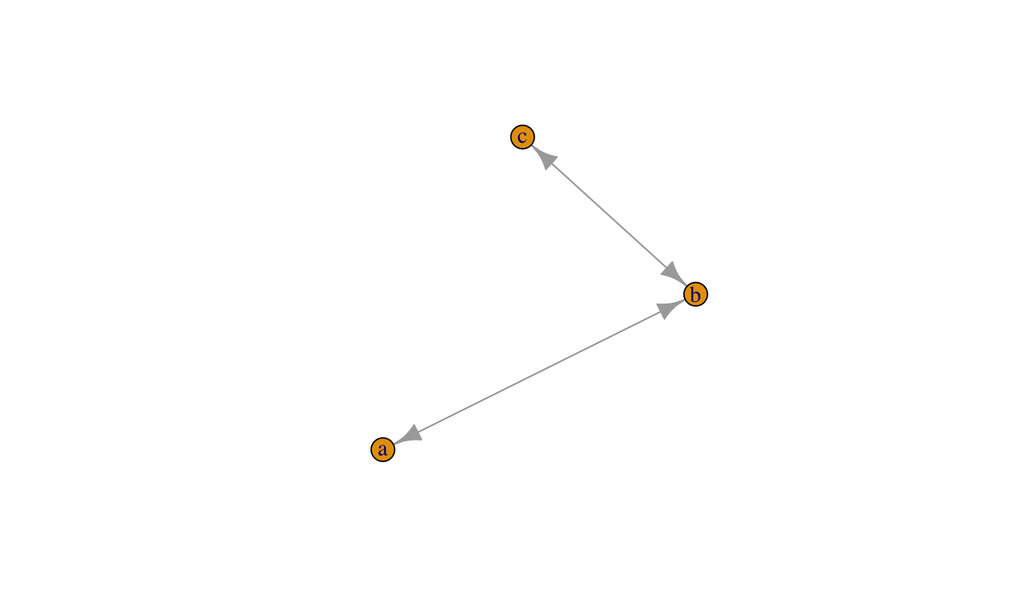

```r
plot(graph_from_literal(a+-+b, b+-+c))
```

a:b:c using colon to connect abc as a whole group. Each vertex within group a:b:c is connected to each vertex within group c:d:e

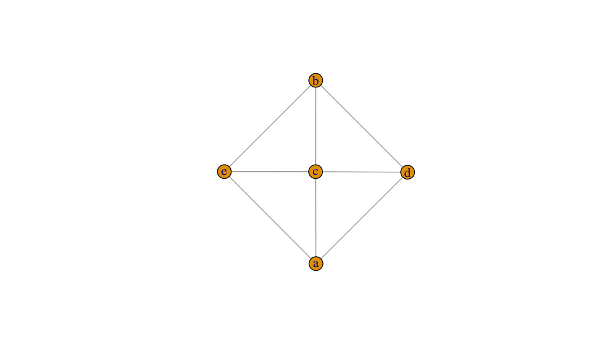

```r
plot(graph_from_literal(a:b:c---c:d:e))
```

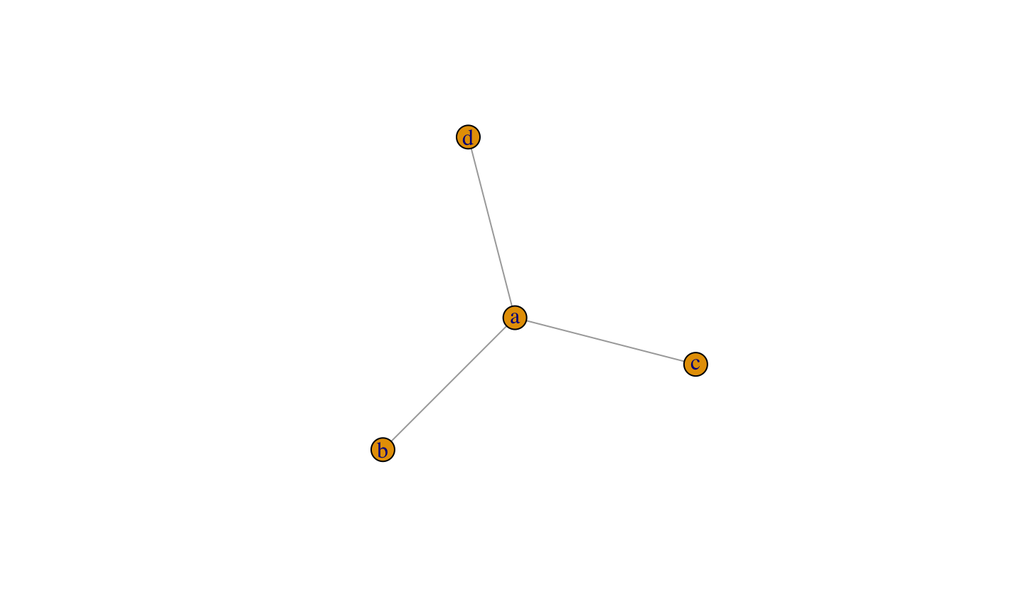

```r
plot(graph_from_literal(a--b:c:d))
```

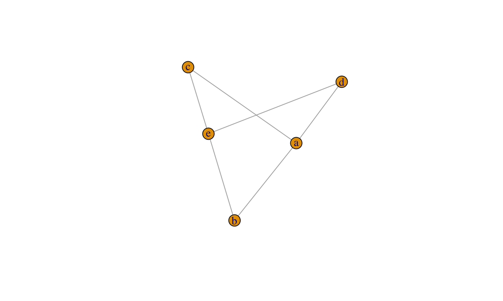

```r
plot(graph_from_literal(a:e--b:c:d))
```

## 2. Creating specific graphs and graph models

- Specific graph
  - `make_empty_graph`
  - `make_full_graph`
  - `make_tree`
  - `make_star`
  - `make_ring`
- Graph models
  - `sample_gnm` Erdos-Renyi random graph
  - `sample_gnp` Erdos-Renyi with G(n,p) specification
  - `sample_smallworld` Watts-Strogatz small-world model
  - `sample_pa` Barabasi-Albert preferential attachment model for scale-free graphs

## Empty graph

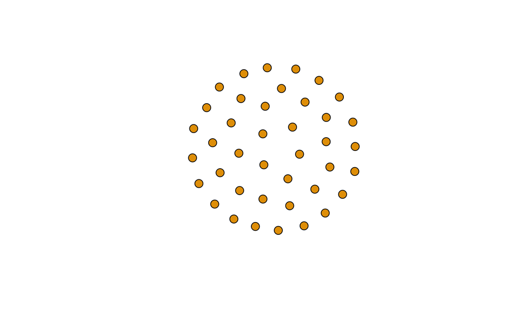

```r
eg <- make_empty_graph(40)
plot(eg, vertex.size=10, vertex.label=NA)
```

## Full graph

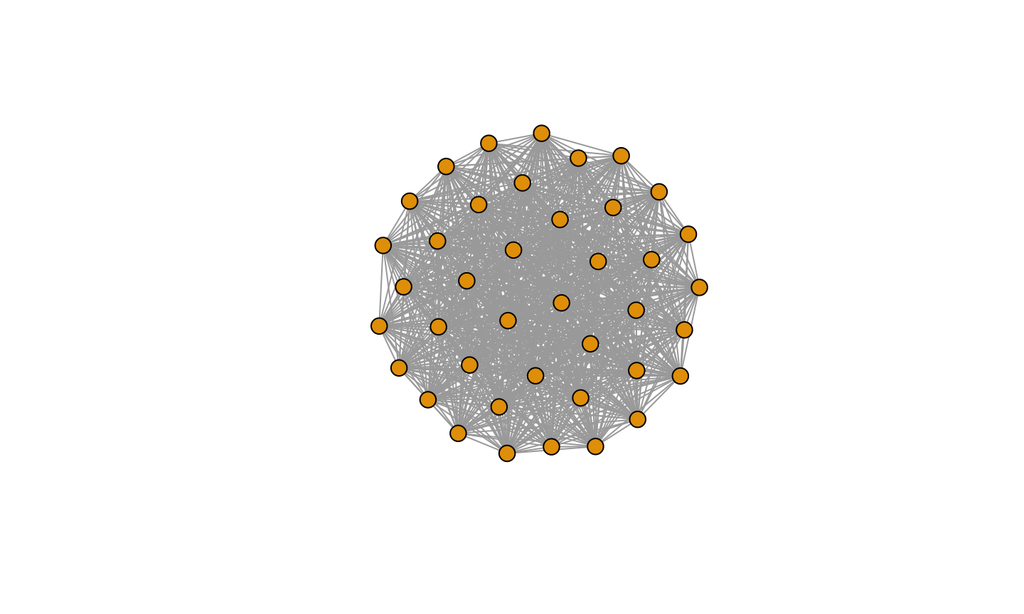

```r
fg <- make_full_graph(40)
plot(fg, vertex.size=10, vertex.label=NA)
```

## Tree graph

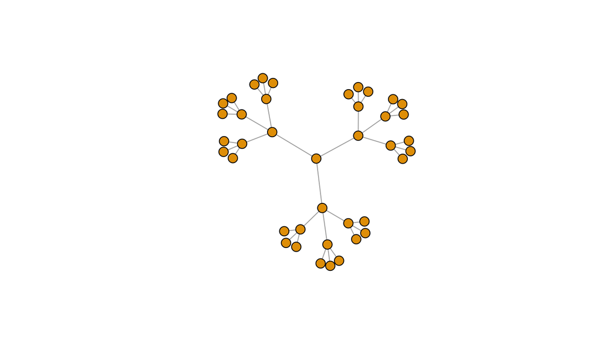

```r
tr <- make_tree(40, children = 3, mode = "undirected")

plot(tr, vertex.size=10, vertex.label=NA)
```

## Star graph

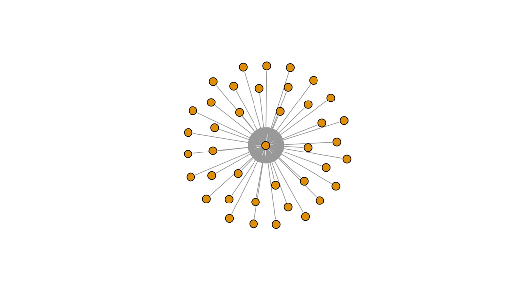

```r
st <- make_star(40)
plot(st, vertex.size=10, vertex.label=NA)
```

## Ring graph

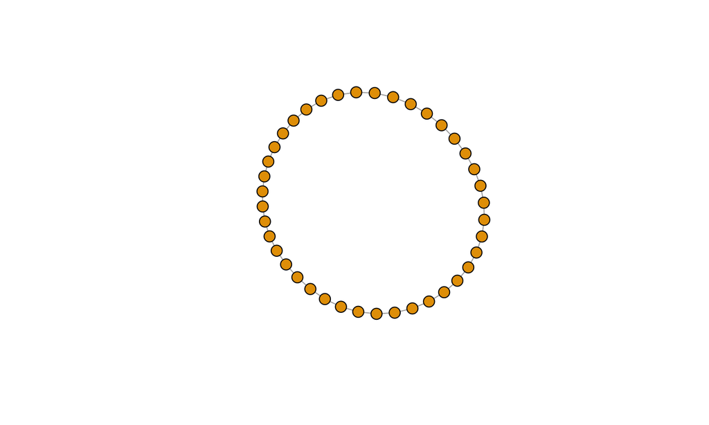

```r
rn <- make_ring(40)
plot(rn, vertex.size=10, vertex.label=NA)
```

## Erdos-Renyi random graph

'n' is number of nodes, 'm' is the number of edges

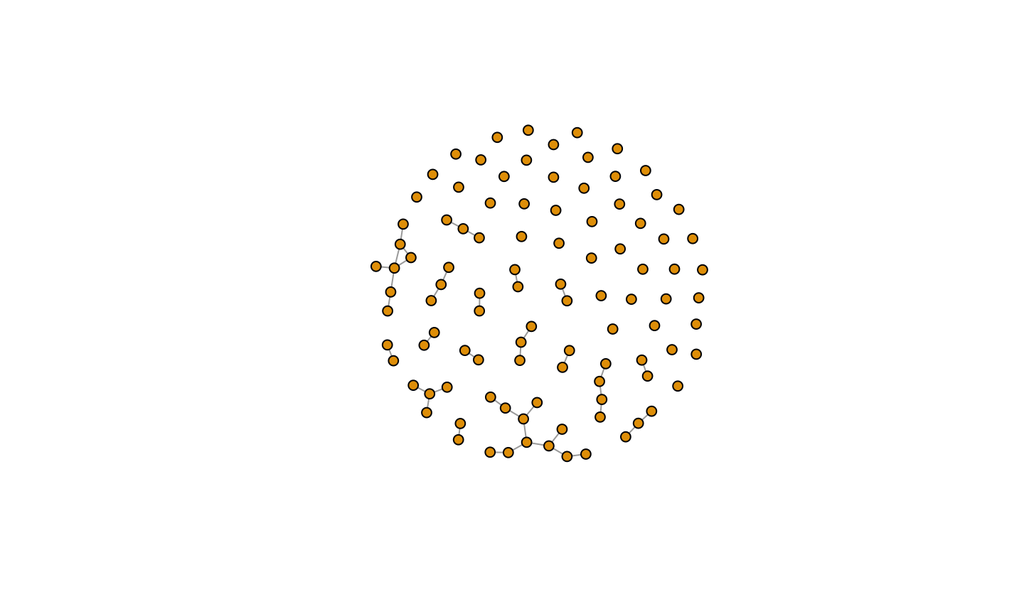

```r
er <- sample_gnm(n=100, m=40) ####can also use erdos.renyi.game
## options include directed= and loops=
plot(er, vertex.size=6, vertex.label=NA)
```

## Erdos-Renyi with G(n,p) specification

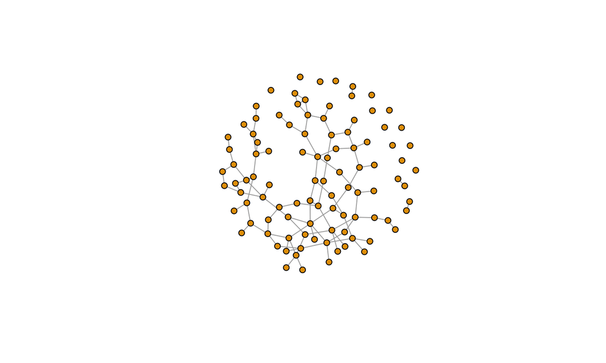

```r
er <- sample_gnp(n=100, p=.02) ####can also use erdos.renyi.game
plot(er, vertex.size=6, vertex.label=NA)
```

## 3. Adjustments on graphs

- igraph object as a layer (using `+`)
- igraph object as a matrix (using `[]`)
- rewiring a graph using `rewire`, `connect.neighborhood`
- combine graphs `%du%`
- other functions

## igraph object as a layer

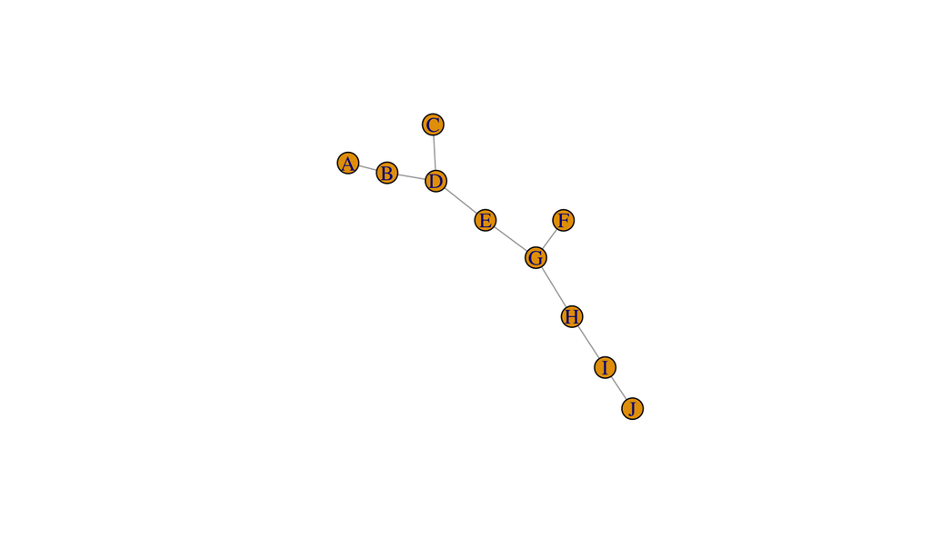

```r
kite <- make_empty_graph(directed = FALSE) + vertices(LETTERS[1:10]) +
edges('A','B', 'B','D', 'C','D', 'D','E', 'E','G', 'F','G', 'G','H', 'H','I', 'I','J')
plot(kite)
```

## igraph object as a matrix

```r
kite[]
```

```
## 10 x 10 sparse Matrix of class "dgCMatrix"
```

```
##    [[ suppressing 10 column names 'A', 'B', 'C' ... ]]
```

```
##
## A . 1 . . . . . . . .
## B 1 . . 1 . . . . . .
## C . . . 1 . . . . . .
## D . 1 1 . 1 . . . . .
## E . . . 1 . . 1 . . .
## F . . . . . . 1 . . .
## G . . . . 1 1 . 1 . .
## H . . . . . . 1 . 1 .
## I . . . . . . . 1 . 1
## J . . . . . . . . 1 .
```

add edge

```r
kite['A','F']=1
kite[]
```

```
## 10 x 10 sparse Matrix of class "dgCMatrix"
```

```
##    [[ suppressing 10 column names 'A', 'B', 'C' ... ]]
```

```
##
## A . 1 . . . 1 . . . .
## B 1 . . 1 . . . . . .
## C . . . 1 . . . . . .
## D . 1 1 . 1 . . . . .
## E . . . 1 . . 1 . . .
## F 1 . . . . . 1 . . .
## G . . . . 1 1 . 1 . .
## H . . . . . . 1 . 1 .
## I . . . . . . . 1 . 1
## J . . . . . . . . 1 .
```

add multiple edges

```r
kite[-1,1]
```

```
## B C D E F G H I J
## 1 0 0 0 1 0 0 0 0
```

```r
kite[-1,1]=1
kite[] # add multiple edges or using from and to
```

```
## 10 x 10 sparse Matrix of class "dgCMatrix"
```

```
##    [[ suppressing 10 column names 'A', 'B', 'C' ... ]]
```

```
##
## A . 1 1 1 1 1 1 1 1 1
## B 1 . . 1 . . . . . .
## C 1 . . 1 . . . . . .
## D 1 1 1 . 1 . . . . .
## E 1 . . 1 . . 1 . . .
## F 1 . . . . . 1 . . .
## G 1 . . . 1 1 . 1 . .
## H 1 . . . . . 1 . 1 .
## I 1 . . . . . . 1 . 1
## J 1 . . . . . . . 1 .
```

add multiple edges using `from` and `to`

```r
kite[from=LETTERS[1:3],to=LETTERS[4:6]]=1
kite[]
```

```
## 10 x 10 sparse Matrix of class "dgCMatrix"
```

```
##    [[ suppressing 10 column names 'A', 'B', 'C' ... ]]
```

```
##
## A . 1 1 1 1 1 1 1 1 1
## B 1 . . 1 1 . . . . .
## C 1 . . 1 . 1 . . . .
## D 1 1 1 . 1 . . . . .
## E 1 1 . 1 . . 1 . . .
## F 1 . 1 . . . 1 . . .
## G 1 . . . 1 1 . 1 . .
## H 1 . . . . . 1 . 1 .
## I 1 . . . . . . 1 . 1
## J 1 . . . . . . . 1 .
```

remove edge

```r
kite[-1,2]=0
```

## rewiring a graph

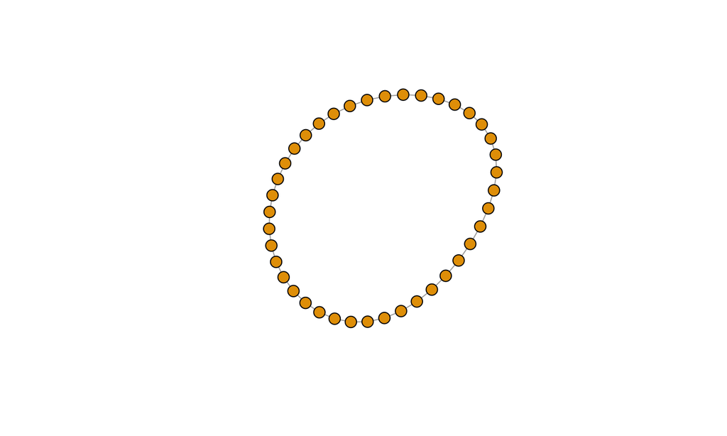

```r
set.seed(1)
plot(rn, vertex.size=10, vertex.label=NA)
```

'each_edge()' is a rewiring method that changes the edge endpoints to a new vertex with a probability 'prob'. And the new vertex is random variable distributed uniformly.

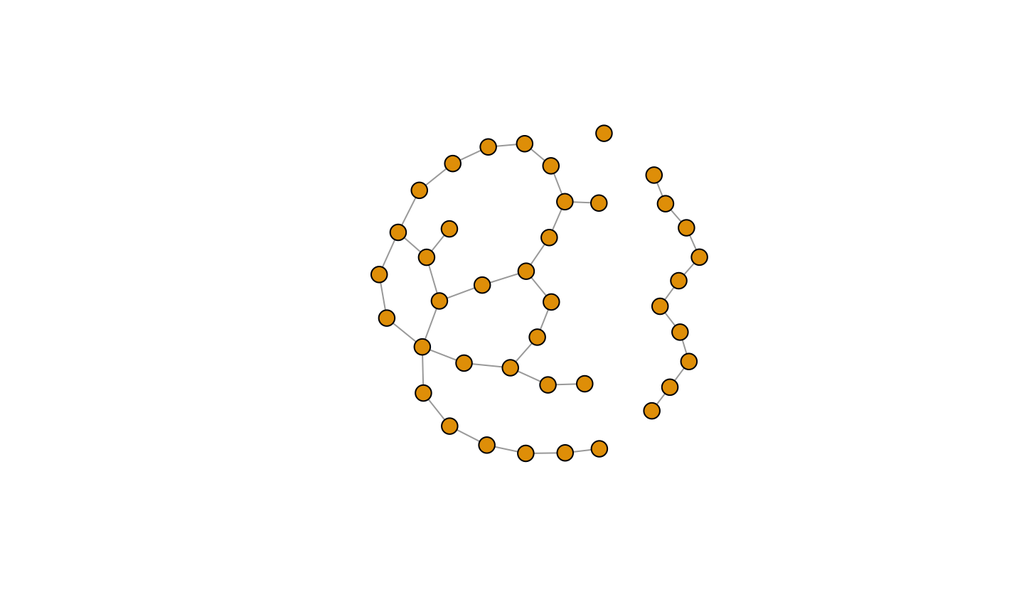

```r
rn.rewired <- rewire(rn, each_edge(prob=0.1))
plot(rn.rewired, vertex.size=10, vertex.label=NA)
```

Rewire to connect vertices to other vertices at a certain distance.

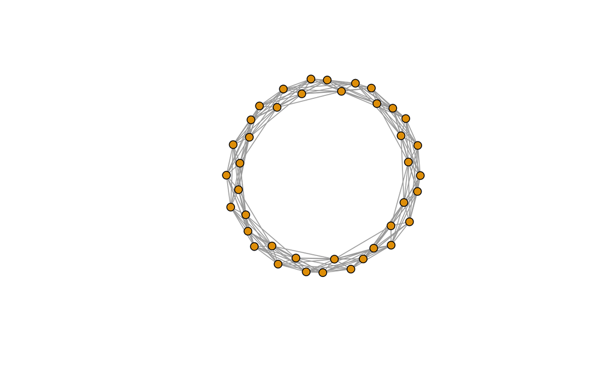

```r
rn.neigh = connect.neighborhood(rn, 5)
plot(rn.neigh, vertex.size=8, vertex.label=NA)
```

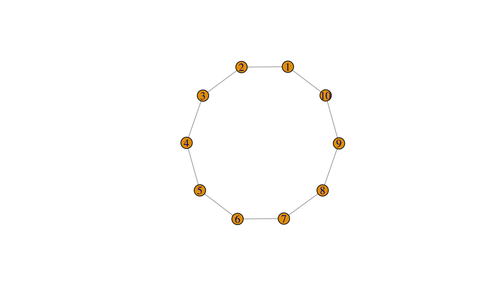

```r
g <- make_ring(10)
plot(g)
```

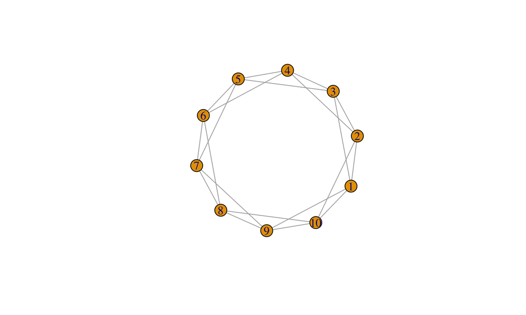

```r
g <- connect(g, 2)
plot(g)
```

combine graphs

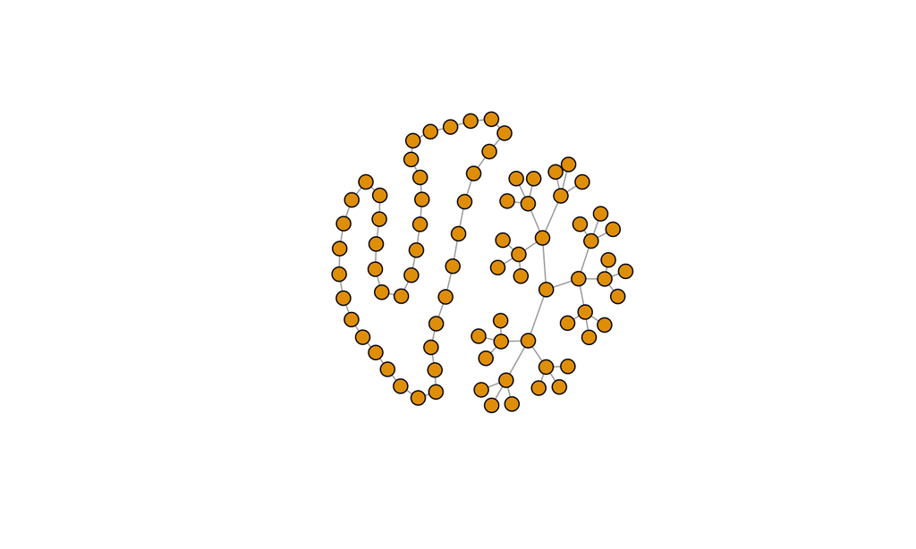

```r
plot(rn %du% tr, vertex.size=10, vertex.label=NA)
```